# R_Presentation

CY

3/15/2019

```r
library("tidyverse")
library("skimr")
```

From the authors of the data source: “The aim of this study was to unravel the role of predation in key pests (A. aurantii) associated with perennial citrus crops by quantifying the importance of species-specific trophic links employing, among others, molecular techniques. Specifically, i) the contribution of predation as a biotic mortality factor of A. aurantiiwas weighted using exclusion techniques and ii) the relative importance of potential predators was assessed through detection of prey DNA in theirgut contents.”

```r
predation <- readr::read_csv("L8/Predation_Data.csv")
#deleted the columns of the comments the authors made in the original data with df <- df [-c(col:col')]
predation <- predation [-c(17:21)]
summary(predation)
```

```
##      CODE               DATE            GENERATION             YEAR
##  Length:652         Length:652         Length:652         Min.   :1.000
##  Class :character   Class :character   Class :character   1st Qu.:1.000
##  Mode  :character   Mode  :character   Mode  :character   Median :1.000
##                                                           Mean   :1.457
##                                                           3rd Qu.:2.000
##                                                           Max.   :2.000
##    LOCATION              TREE       TREE WRIENTATIWN    PLANT PART
##  Length:652         Min.   : 1.00   Length:652         Length:652
##  Class :character   1st Qu.: 4.00   Class :character   Class :character
##  Mode  :character   Median : 7.00   Mode  :character   Mode  :character
##                     Mean   : 7.37
##                     3rd Qu.:11.00
##                     Max.   :16.00
##   TREATMENT           INITIAL N1      SURVIVORS      PREDATED SCALES
##  Length:652         Min.   : 8.00   Min.   : 0.000   Min.   : 0.00
##  Class :character   1st Qu.:15.00   1st Qu.: 0.000   1st Qu.:11.00
##  Mode  :character   Median :21.00   Median : 2.000   Median :17.00
##                     Mean   :22.77   Mean   : 4.706   Mean   :18.06
##                     3rd Qu.:30.00   3rd Qu.: 7.000   3rd Qu.:25.25
##                     Max.   :50.00   Max.   :36.000   Max.   :49.00
##  PARASITISED SCALES   MORTALITY        PARASITISM    CORRECTED MORTALITY
##  Min.   : 0.0000    Min.   :  0.00   Min.   : 0.00   Min.   :-339.62
##  1st Qu.: 0.0000    1st Qu.: 66.70   1st Qu.: 0.00   1st Qu.:  12.29
##  Median : 0.0000    Median : 90.75   Median : 0.00   Median :  73.89
##  Mean   : 0.4202    Mean   : 78.47   Mean   : 2.08   Mean   :  42.47
##  3rd Qu.: 0.0000    3rd Qu.:100.00   3rd Qu.: 0.00   3rd Qu.: 100.00
##  Max.   :13.0000    Max.   :100.00   Max.   :52.90   Max.   : 100.00
```

What does this dataframe look like?

```r
predation %>%
  skimr::skim()
```

```
## Skim summary statistics
##  n obs: 652
##  n variables: 16
##
## ── Variable type:character ─────────────────────────────────────────────────────
##          variable missing complete   n min max empty n_unique
##              CODE       0      652 652   4   5     0      125
##              DATE       0      652 652   7   8     0        9
##        GENERATION       0      652 652   3   3     0        3
##          LOCATION       0      652 652   4   7     0        3
##        PLANT PART       0      652 652   4   5     0        2
##         TREATMENT       0      652 652   9  14     0        3
##  TREE WRIENTATIWN       0      652 652   1   1     0        4
##
## ── Variable type:numeric ───────────────────────────────────────────────────────
##             variable missing complete   n  mean    sd      p0   p25   p50
##  CORRECTED MORTALITY       0      652 652 42.47 73.85 -339.62 12.29 73.88
##           INITIAL N1       0      652 652 22.77  9.33    8    15    21
##            MORTALITY       0      652 652 78.47 26.7     0    66.7  90.75
##   PARASITISED SCALES       0      652 652  0.42  1.3     0     0     0
##           PARASITISM       0      652 652  2.08  6.17    0     0     0
##      PREDATED SCALES       0      652 652 18.06  9.95    0    11    17
##            SURVIVORS       0      652 652  4.71  6.24    0     0     2
##                 TREE       0      652 652  7.37  3.9     1     4     7
##                 YEAR       0      652 652  1.46  0.5     1     1     1
##     p75  p100     hist
##  100    100   ▁▁▁▁▁▁▂▇
##   30     50   ▇▇▆▇▅▃▁▁
##  100    100   ▁▁▁▁▁▂▂▇
##    0     13   ▇▁▁▁▁▁▁▁
##    0     52.9 ▇▁▁▁▁▁▁▁
##   25.25  49   ▃▇▇▆▆▂▁▁
##    7     36   ▇▂▁▁▁▁▁▁
##   11     16   ▇▆▇▇▇▆▅▁
##    2      2   ▇▁▁▁▁▁▁▇
```

```r
names(predation)
```

```
##  [1] "CODE"                "DATE"                "GENERATION"
##  [4] "YEAR"                "LOCATION"            "TREE"
##  [7] "TREE WRIENTATIWN"    "PLANT PART"          "TREATMENT"
## [10] "INITIAL N1"          "SURVIVORS"           "PREDATED SCALES"
## [13] "PARASITISED SCALES"  "MORTALITY"           "PARASITISM"
## [16] "CORRECTED MORTALITY"
```

To understand how A. aurantii individuals’ predation affect the trees they prey on, let’s take a look at the tree samples used in this study! What are their orientations and what parts of them were compared?

```r
predation %>%
  select(TREE, `TREE WRIENTATIWN`, `PLANT PART`, TREATMENT) %>%
  filter(TREATMENT == "Predation") %>%
  arrange(`PLANT PART`)
```

```
## # A tibble: 228 x 4
##     TREE `TREE WRIENTATIWN` `PLANT PART` TREATMENT
##    <dbl> <chr>              <chr>        <chr>
##  1     1 W                  Fruit        Predation
##  2     1 S                  Fruit        Predation
##  3     3 N                  Fruit        Predation
##  4     3 W                  Fruit        Predation
##  5     5 E                  Fruit        Predation
##  6     5 W                  Fruit        Predation
##  7     6 E                  Fruit        Predation
##  8     6 N                  Fruit        Predation
##  9     7 N                  Fruit        Predation
## 10     8 W                  Fruit        Predation
## # … with 218 more rows
```

What are the mortality and parasitism rates after A. aurantii’s predation?

```r
predation %>%
  select(TREE, TREATMENT, MORTALITY, PARASITISM) %>%
  filter(TREATMENT == "Predation") %>%
  arrange(-`MORTALITY`)
```

```
## # A tibble: 228 x 4
##     TREE TREATMENT MORTALITY PARASITISM
##    <dbl> <chr>         <dbl>      <dbl>
##  1     1 Predation       100        0
##  2     6 Predation       100        0
##  3     9 Predation       100        0
##  4    11 Predation       100        0
##  5     1 Predation       100        0
##  6     3 Predation       100        9.1
##  7     5 Predation       100        0
##  8     6 Predation       100        0
##  9    10 Predation       100        0
## 10     1 Predation       100        7.7
## # … with 218 more rows
```

Let’s see if there is a correlation between predation and tree mortality!

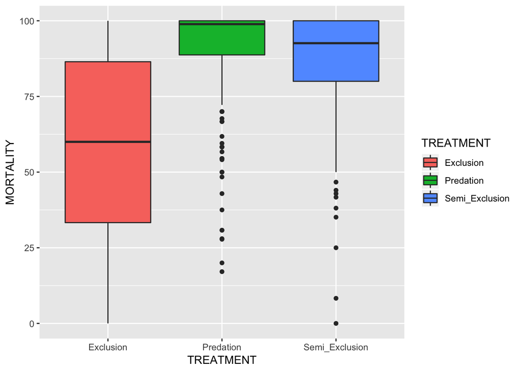

```r
ggplot(data=predation, mapping=aes(x=TREATMENT, y=MORTALITY, group = TREATMENT, fill = TREATMENT)) +
  geom_boxplot()
```

Are trees that became parasited more prone to die?

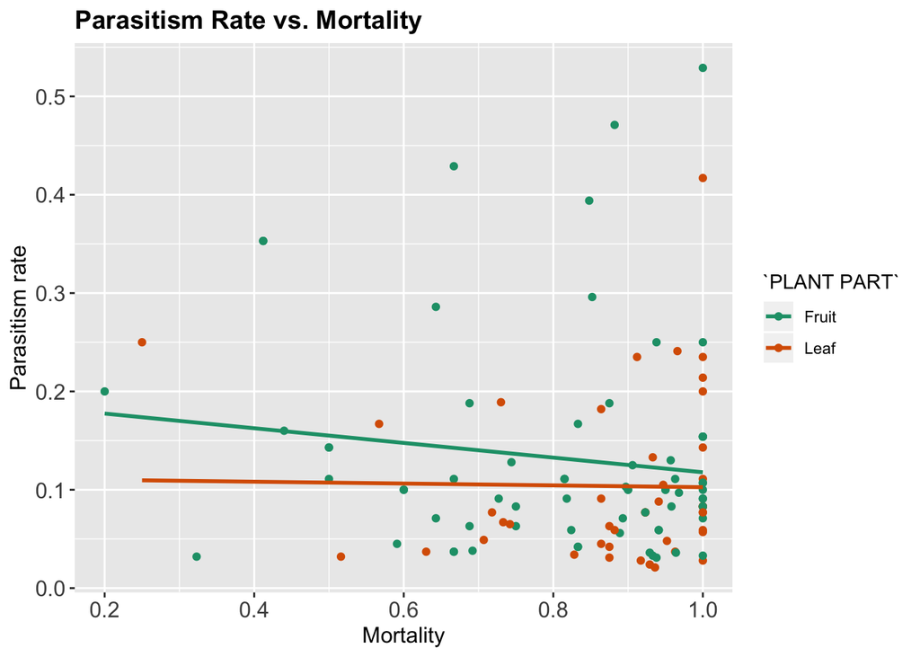

```r
predation %>%
  filter(PARASITISM > 1) %>%
  ggplot(mapping=aes(y=0.01 * PARASITISM, x= 0.01 * MORTALITY, color = `PLANT PART`)) +
  geom_point()+
  scale_colour_brewer(palette = "Dark2")+
  geom_smooth(method = lm, se = FALSE)+
  labs(title = "Parasitism Rate vs. Mortality",
       y = "Parasitism rate",
       x = "Mortality")+
  theme(plot.title = element_text(size = 14, face = "bold"),
        axis.text = element_text(size = 12),
        axis.title = element_text(size = 12))
```

Do A. aurantii smaple individuals have a favorite part of the tree to predate on?

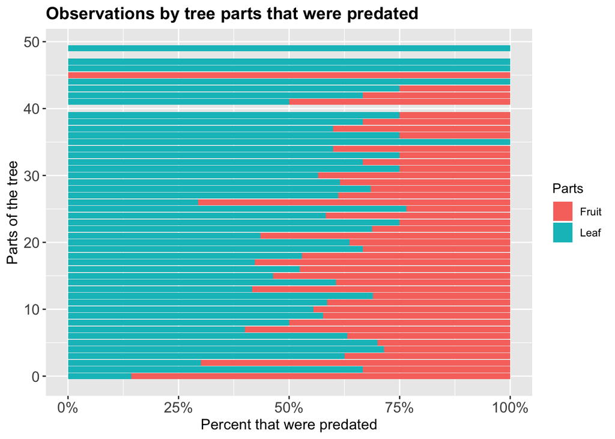

```r
predation %>%
  ggplot(aes(x=`PREDATED SCALES`, fill=`PLANT PART`))+
  geom_bar(position = position_fill(), stat = "count")+
  scale_y_continuous(labels = scales::percent)+
  labs(title = "Observations by tree parts that were predated",
       x = "Parts of the tree",
       y = "Percent that were predated",
       fill= "Parts")+
  coord_flip()+
  theme(plot.title = element_text(size = 14, face = "bold"),
        axis.text = element_text(size = 12),
        axis.title = element_text(size = 12))
```

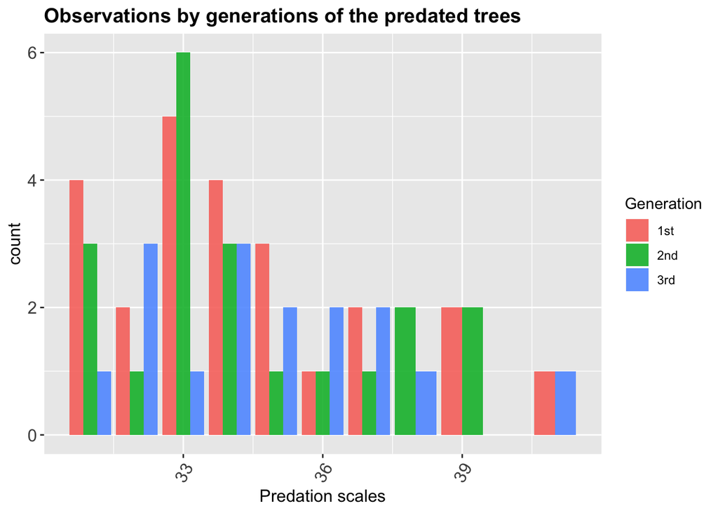

```r
predation %>%
  filter(`PREDATED SCALES` > 30 & `PREDATED SCALES` < 42) %>%
  ggplot(aes(x=`PREDATED SCALES`, fill=`GENERATION`))+
geom_bar(alpha=0.9, na.rm=T, position="dodge")+
  theme(legend.position = "right",
        axis.text.x = element_text(angle = 60, hjust=1))+
  labs(title = "Observations by generations of the predated trees",
       x = "Predation scales",
       fill= "Generation")+
theme(plot.title = element_text(size = 14, face = "bold"),
        axis.text = element_text(size = 12),
        axis.title = element_text(size = 12))
```

We now know that there is a positive correlation between mortality and A. aurantii predation, does that have anything to do with the aurantii individuals’ preferred parts of the tree?

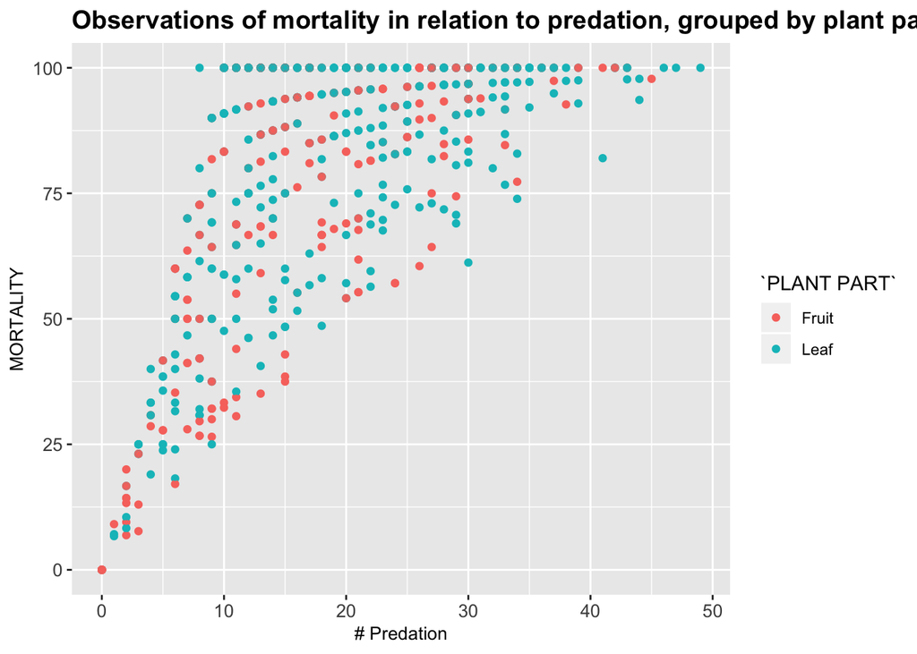

```r
predation %>%
  ggplot(aes(x=`PREDATED SCALES`, y=MORTALITY, color=`PLANT PART`))+
  geom_point()+
  geom_point(shape = 18)+
  labs(title = "Observations of mortality in relation to predation, grouped by plant parts",
       x = "# Predation",
       fill= "Plant Parts")+
  theme(plot.title = element_text(size = 14, face = "bold"),
        axis.text = element_text(size = 10),
        axis.title = element_text(size = 10))
```

Now, let’s see if mortality rate has a different distribution between different parts of the sample trees!

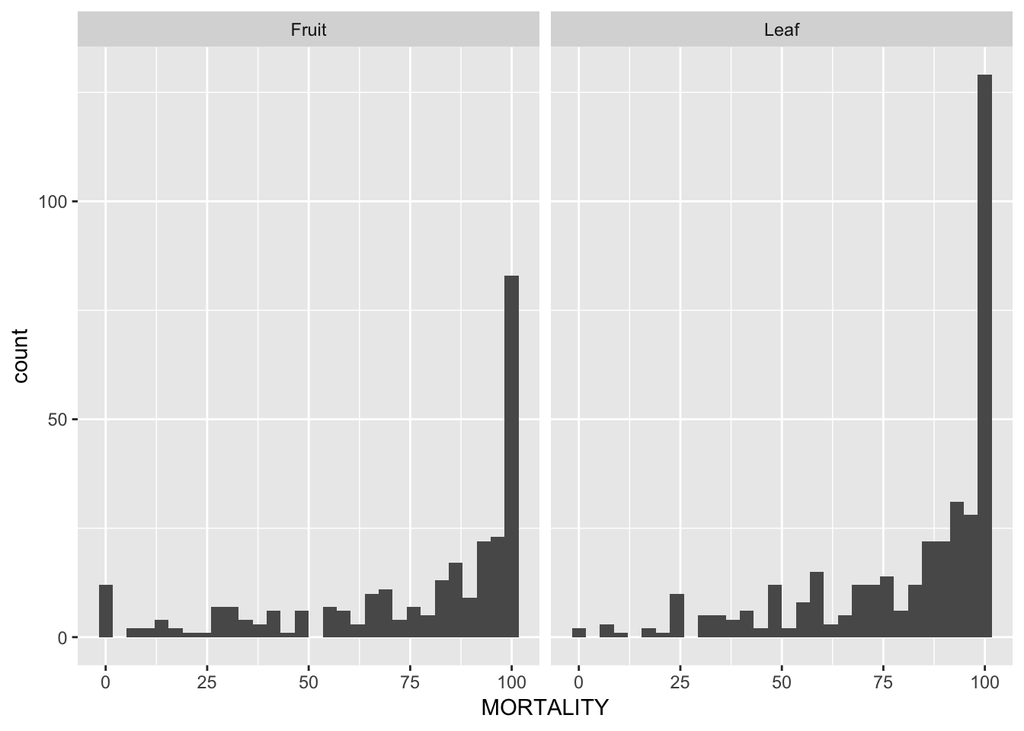

```r
predation %>%
  ggplot(aes(x = MORTALITY)) +
  geom_histogram() +
  facet_wrap(~`PLANT PART`)
```

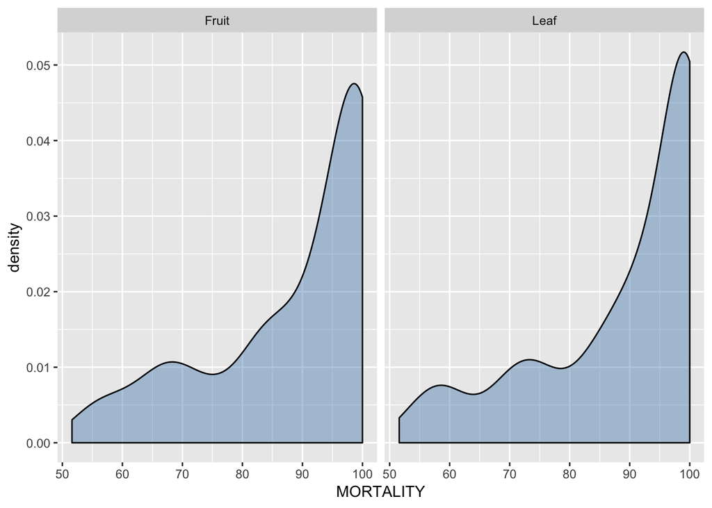

```r
predation %>%
  filter(MORTALITY > 50) %>%
  ggplot(aes(x = MORTALITY)) +
  geom_density(fill="steelblue", alpha=0.4)+
  facet_wrap(~`PLANT PART`)
```